# Series temporales en R

## 4.4 Graficas de dispersión o Scatterplots

Si queremos hallar relaciones entre variables de una tabla temporal, tenderemos que hacer muchas gráficas de dispersión comparando cada observación de la variable x con la observación de la misma fecha de la variable y.

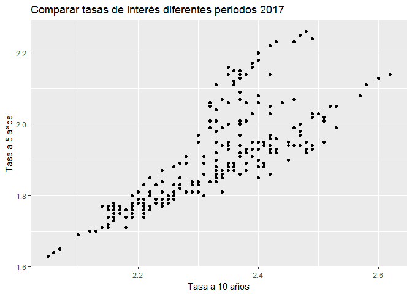

```r
    library(ustyc)
    # obtener lacurva de rendimiento
    my.yield.curve <- getYieldCurve(year = 2017)
    # me guardo la tabla de curva de intereses
    curva.de.interes<-na.omit(my.yield.curve$df)
    # Quito las filas con ceros
    curva.de.interes<-curva.de.interes[apply(curva.de.interes!=0, 1, all),]

    qplot(BC_10YEAR, BC_5YEAR, data=curva.de.interes) +
        ylab("Tasa a 5 años") + xlab("Tasa a 10 años") +
        ggtitle("Comparar tasas de interés diferentes periodos 2017")
```

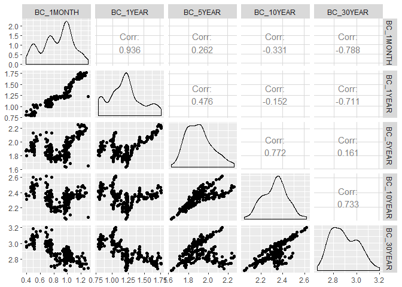

```r
    # para ver las relaciones de todos con todos en un data frame
    # vamos a representar las relaciones de todos
    require(GGally) # paquete para pintar el grafico
    curva.de.interes[,c(1,4,7,9,11)] %>% GGally::ggpairs()
```

## 4.5 Autocorrelogramas

Otra forma de ver los datos de series de tiempo es trazar cada observación contra otra observación que ocurrió algún tiempo antes. Esto es lo que llamamos gráficas de retardo y puede hacerse con la función `gglagplot()`.

Por ejemplo, trazar
$$y_t$$
contra
$$y_{t-_1}$$
. Esto se llama **diagrama de retardo** porque está trazando la serie temporal contra los retardos (*lag*) de sí misma.

Si calculamos el coeficiente de correlación de los datos de cada gráfica de retardo, obtenemos una gráfica muy interesante que llamamos **grafica de autocorrelación (ACF)** de la serie o **autocorrelogramas**. Esta gráfica nos aporta mucha infomación valiosa para interepretar los datos, la existencia o no de ciclos, la magnitud de estos y la relación entre intervalos temporales. En R la función que usamos para pintarla es `ggAcf()`.

La variación de la gráfica de autocorrelación según el retardo es lo que denominamos **gráfica de autocorrelación parcial (PACF)**, es como la derivada de la función ACF. Las graficas de PACF son importantes como veremos para determinar los parametros de los modelos de regresión lineal ARIMA.

### 4.5.1 Autocorrelación en series no estacionales

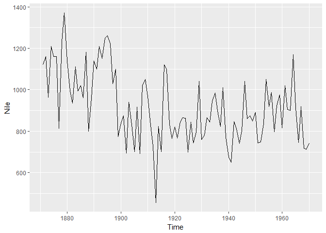

```r
    library(ggplot2)
    # Pintar la serie temporal completa
    autoplot(Nile)
```

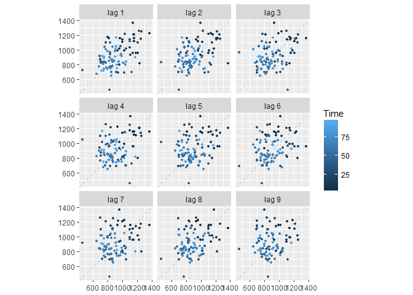

```r
    # Pintar la grafica de autocorrelaciones
    gglagplot(Nile,do.lines=FALSE)
```

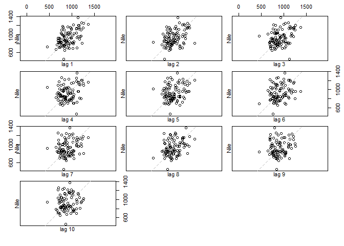

```r
    # Tambien puede hacerse con la función lag.plot
    lag.plot(Nile, lags=10, do.lines =FALSE)
```

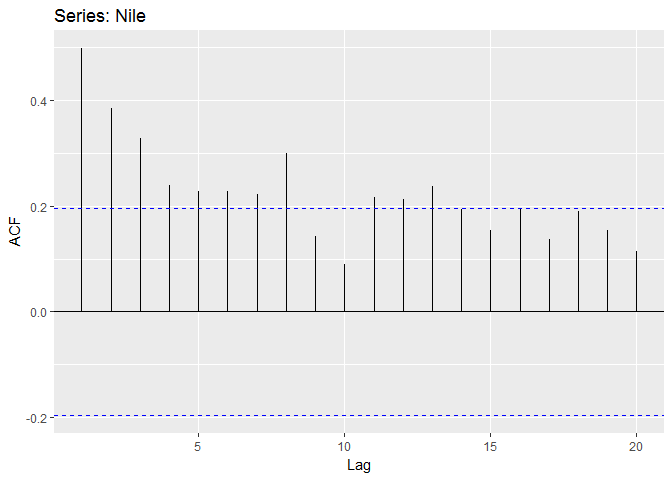

```r
    # Pintar la grafica de autocorrelación
    ggAcf(Nile)
```

Vamos a investigar el fenómeno de manchas solares con los datos disponibles en la base de datos `sunspot.year` y comprobar que exste un ciclo de 10-11 años en los que se repite la insensidad de las mismas.

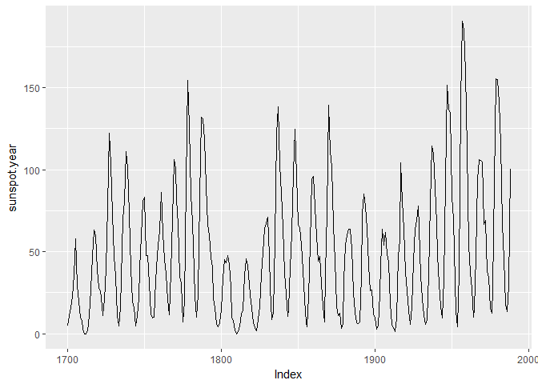

```r
    require(ggplot2)
    require("forecast")
    # Creamos el grafico de numero de manchas solares con el año.
    #autoplot(sunspot.year)
    autoplot.zoo(sunspot.year)
```

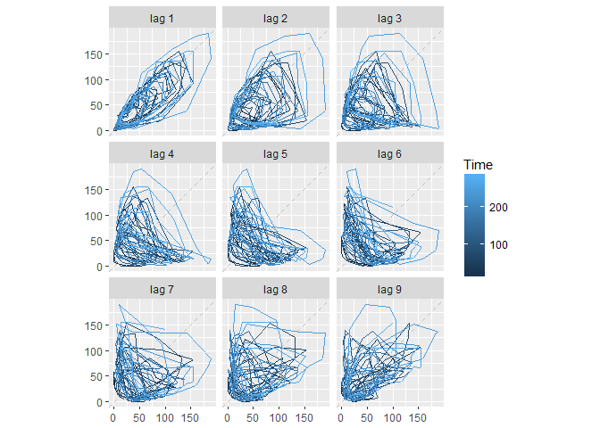

```r
    # Creamos un grafico de restrasos con los datos
    gglagplot(sunspot.year)
```

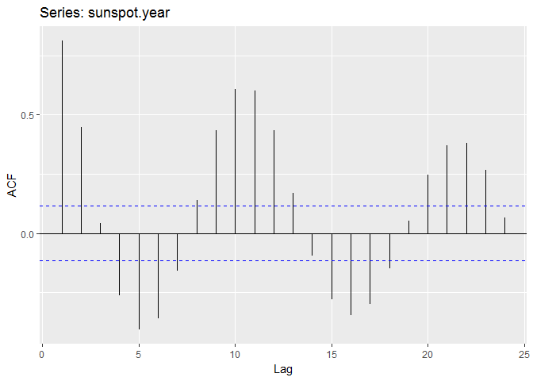

```r
    # Creamos un grafico ACF
    ggAcf(sunspot.year)
```

Como vemos en el gráfico, las bandas azules indican los limites de ruido blanco. Si la autocorrelación es menor que esas marcas cuyo valor es
$$\pm 2 / \sqrt{T}$$
donde
$$T$$
es el numero de observaciones, es idicativo de que se trata de ruido blanco.

## 4.6 Test de Ruido blanco

El ruido blanco es un término que describe datos puramente aleatorios. Para comprobar si una serie es o no ruido blanco se puede realizar la prueba de *Ljung-Box* utilizando la función `Box.test (serie, lag = 24, fitdf = 0, tipo = "Ljung")`.

Si el resultado de `p` es un valor mayor que **0.05** se sugiere que los datos no son significativamente diferentes del ruido blanco, y si es inferio es posible que los datos sean predecibles pues se diferencian del ruido blanco.

Vamos a comprobar la “Hipótesis del mercado eficiente” que establece que los precios de los activos reflejan toda la información disponible, por lo que no son predecibles son independientes de los valores anteriores. Una consecuencia de esto es que los cambios diarios en los precios de las acciones deben comportarse como *ruido blanco* (ignorando los dividendos, las tasas de interés y los costos de transacción). La consecuencia para los pronosticadores sería que el mejor pronóstico del precio futuro es el precio actual.

```r
    # leemos los datos de la web con quandmod
library("quantmod")
    valor1<-getSymbols("goog", from ="2016-09-15", to ="2017-02-13", src ="yahoo", warning= "FALSE",adjust = TRUE,auto.assign=FALSE)
    # numero de días de los datos
    ndays(valor1)
```

```
## [1] 103
```

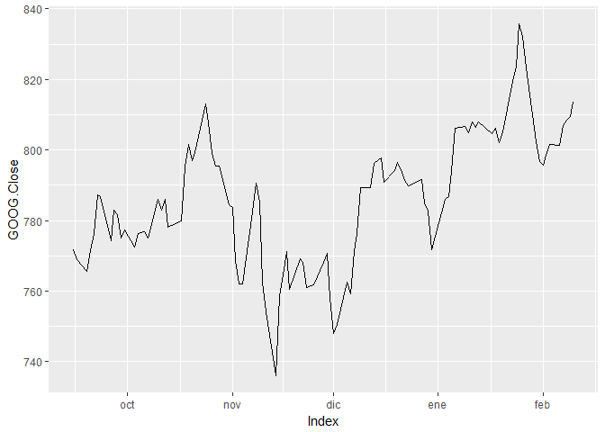

```r
    # pintamos la serie origen
    autoplot(Cl(valor1))
```

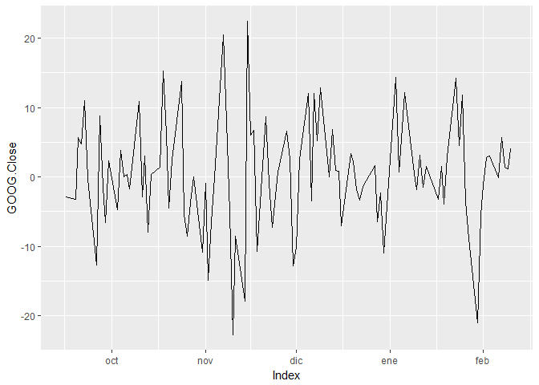

```r
    # Pintamos la serie de diferencias
    autoplot(diff(Cl(valor1)))
```

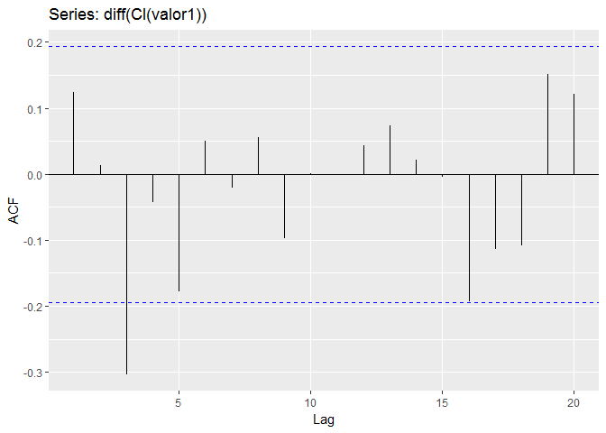

```r
    #Pintamos la grafica de retrasos de autocorrelación
    ggAcf(diff(Cl(valor1)))
```

```r
    # Por último realizamos el test de Ljung-Box
    # sobre la serie de diferencias
    Box.test(diff(Cl(valor1)), lag = 1, type = "Ljung")
```

```
##
##  Box-Ljung test
##
## data:  diff(Cl(valor1))
## X-squared = 1.6217, df = 1, p-value = 0.2029
```

# 5 PREDICIONES SIMPLES

Un pronóstico es la estimación del valor fururo de una serie temporal. No es difícil hacer predicciones a futuro en base a unos datos iniciales, la prueba es que existen métodos simples que han sido usados profusamente incluso con buenos resultados. En otras ocasiones es necesario conocer estas fórmulas sencillas de pronóstico para comparar sus resultados con otros modelos complejos y estimar su calidad, recordemos que el *principio de parsimonia* nos indica que las soluciones más simples suelen ser las correctas.

Veremos en este capítulo 4 modelos de pronóstico de formulación muy sencilla, contenidas dentro del paquete `forecast` de R:

```
- método de la media: `meanf()`
- pronóstico simple: `naive()`
- pronóstico simple estacional: `snaive()`
- modelo lineal:  `rwf()`
```

## 5.1 Método de la media

Se trata simplemente de estimar el valor futuro de la serie como el valor medio de las observaciones dadas hasta la fecha de pronóstico. La función de desarrolla el modelo es `meanf()`

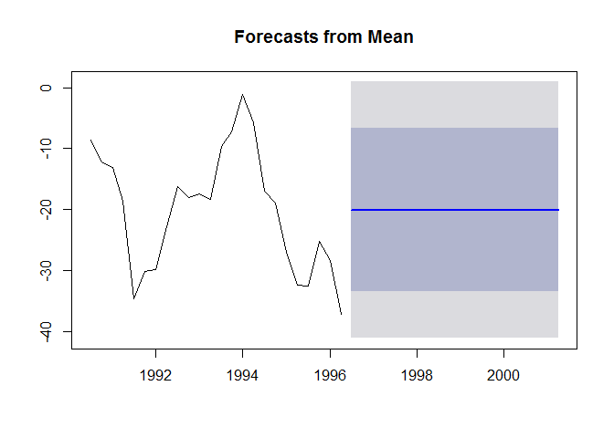

```r
    require(forecast)
    # Usamos la serie ts de ejemplo del cap1
    # creamos un pronostico simple de media
    p.med<-meanf(mits,20)
    #Pintamos el pronostico
    plot(p.med)
```

## 5.2 Pronóstico simple o ingenuo

El método de pronóstico simple consiste en usar la última observación, la más reciente, como valor de predicción para el futuro próximo, esto es lo que se conoce como *pronóstico ingenuo*. Puede parecer tonto, pero existe una función específica para su calculo `naive()`y es, en muchas ocasiones el mejor pronóstico que podemos ofrecer.

Esta estimación sencilla es lo mejor que se puede tener para muchas series temporales, incluida la mayoría de los datos sobre el precio de las acciones, e incluso si no es un buen método de pronóstico, proporciona un punto de referencia útil para comparar con otros.

Para los datos estacionales o cíclicos, una idea similar es establecer como pronóstico el último valor de la misma temporada que la actual. Por ejemplo, si deseamos pronosticar el volumen de ventas para el próximo marzo, usaríamos el volumen de ventas del marzo del año anterior. Esto se implementa en la función `snaive()`(*sesonal naive*, es decir, ingenuo de temporada).

```r
    # pronostico ingenuo en serie tendencial
    naive(y, h = 10) ;

    # pronostico ingenuo en serie cíclica estacional
    snaive(y, h = 2 * frequency(y))`
```

El paquete de R `forecast`nos facilita el uso de pronósticos sobre series temporales y contiene unas ayudas gráficas que representan la información de manera intuitiva y límpia. Además la clase principal de objetos en el paquete `forecast` contiene muchas funciones para manejarlos, incluyendo `summary()` y `autoplot()`.

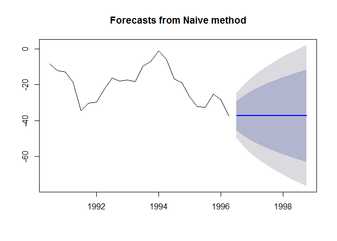

```r
    require(forecast)
    # Usamos naive() para hacer un pronostico ingenuo de la serie por 10 días
    p.simple <- naive(mits, 10)

    # Pintamos el pronóstico y el resumen
    plot(p.simple)
```

```r
    summary(p.simple)
```

```
##
## Forecast method: Naive method
##
## Model Information:
## Call: naive(y = mits, h = 10)
##
## Residual sd: 6.3414
##
## Error measures:
##                     ME     RMSE    MAE       MPE     MAPE      MASE
## Training set -1.247139 6.326138 5.0299 -17.43698 49.24824 0.3898674
##                   ACF1
## Training set 0.2012683
##
## Forecasts:
##         Point Forecast     Lo 80     Hi 80     Lo 95        Hi 95
## 1996 Q3      -37.23004 -45.33731 -29.12276 -49.62904 -24.83103409
## 1996 Q4      -37.23004 -48.69545 -25.76462 -54.76487 -19.69519920
## 1997 Q1      -37.23004 -51.27224 -23.18783 -58.70574 -15.75433449
## 1997 Q2      -37.23004 -53.44458 -21.01549 -62.02804 -12.43203185
## 1997 Q3      -37.23004 -55.35845 -19.10163 -64.95505  -9.50502447
## 1997 Q4      -37.23004 -57.08872 -17.37136 -67.60127  -6.85880752
## 1998 Q1      -37.23004 -58.67986 -15.78021 -70.03471  -4.42535990
## 1998 Q2      -37.23004 -60.16086 -14.29921 -72.29971  -2.16036207
## 1998 Q3      -37.23004 -61.55185 -12.90822 -74.42704  -0.03302961
## 1998 Q4      -37.23004 -62.86748 -11.59259 -76.43912   1.97905146
```

Otro ejemplo con lectura de fichero Excel:

```r
    require(forecast)
    require(xlsx)

    paro.Murcia<-read.xlsx("sec1.xls", sheetIndex = 2, header = T)
    #, colIndex = "1:2")#, rowIndex ="7:120")

    paro<-xts(paro.Murcia[,2], order.by = as.Date(paro.Murcia[,1],"%Y-%m-%d %R"))
    colnames(paro)<-"Total_paro"
    head(paro)
```

```
##            Total_paro
## 2009-01-01      97659
## 2009-02-01     101894
## 2009-03-01     105889
## 2009-04-01     107773
## 2009-05-01     106737
## 2009-06-01     106148
```

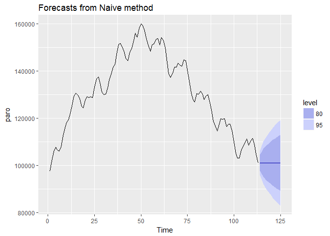

```r
    # Usamos naive() para hacer un pronostico ingenuo de la serie por 10 días
    p.simple <- naive(paro, 12)

    # Pintamos el pronóstico y el resumen
    autoplot(p.simple)
```

## 5.3 Pronóstico simple estacional

Para series estacionales la función de pronóstico simple añade una `s` inicial `snaive()`. Veamos un ejemplo de uso.

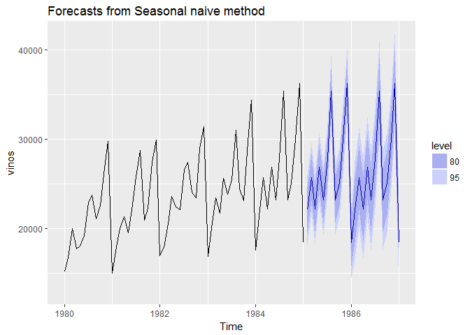

```r
    # Usaremos una serie estacinal como wineind
    # seleccionamos un tramo de la serie que acaba en 1985
    vinos<-window(wineind,end=1985)
    # realizamos el pronostico simple estacional para 2 años
    p.simple <- snaive(vinos, 24)

    # Pintamos el pronóstico
    autoplot(p.simple)
```

## 5.4 Método lineal

El método lineal extrapola los valores futuros en base a las dos ultimas observaciones, con una simple interpolación lineal de los datos.

Este método está tambien incluido en el paquete `forecast` mediante la función `rwf(y, h, drift=TRUE)`.

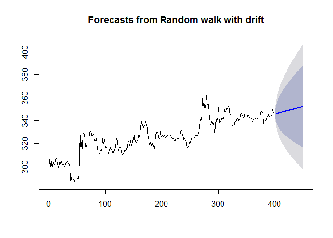

```r
    # Pronostico lineal
    # usaremos la serie del oro
    # realizamos un pronostico simple para 50 pasos futuros
    p.simple <- rwf(gold[1:400], 50,drift=TRUE)

    # Pintamos el pronóstico
    plot(p.simple)
```

# 6 EVALUACIÓN DE PRONÓSTICOS

Vamos a ver fórmulas que nos permitan evaluar la bondad de las predicciones que realizamos. Estas funciones se basan principalmente en medir la diferencia entre el valor pronosticado y el observado en la realidad.

## 6.1 Residuos del pronóstico, función tubería

Llamamos *residuos* (
$$e_t$$
) a las diferencias entre cada valor pronosticado
$$\hat{y_t}$$
al aplicar el modelo sobre los datos y su correspondiente valor observado
$$y_t$$
. Estas diferencias, para cada punto del pronóstico forman una nueva variable aleatoria, que podemos estudiar y que debe cumplir unas características adecuadas para asegurar que el modelo es correcto.

$$e_t = y_t - \hat{y_t}$$

Por ejemplo, es bueno que los residuos sean pequeños, que tengan un comportamiento de ruido blanco y distribución normal de sus valores, esto indicaría que la parte de residuo **que no pronostica el modelo** es mínima e impredecible. En jerga estadística (regresion lineal) lo que se busca es que se cumplan en los residuos las premisas de linealidad, homocedasticidad y normalidad (http://tabarefernandez.tripod.com/coco2.pdf).

Por tanto, para analizar el buen comportamiento del modelo de pronóstico es importante verificar siempre que los **residuos** se comporten bien, esto es: sin valores atípicos, ni patrones y que se asemejen al ruido blanco y que se distribuya normalmente.

La función `checkresiduals()` se usa para verificar estas características y entre ellas aporta el resultado de la prueba de `Ljung-Box` sobre el ruido blanco.

Para probar esta función es habitual el uso de la función de tubería (*%>%*) en el código R. Esta función es útil cuando hay funciones anidadas, en las que el resultado de una es tomado de entrada en la siguiente. Las funciones de tubería hacen que el código sea mucho más fácil de leer.

Vamos a calcular los residuos de las funciones de pronóstico anteriores usando tambien la función tubería.

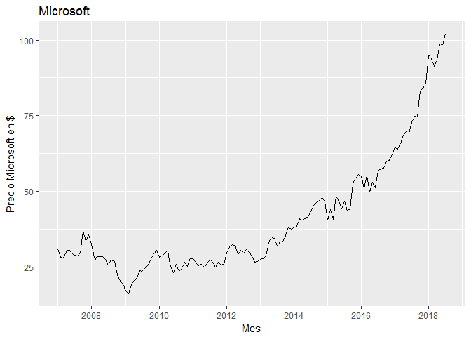

```r
    require(quantmod)
    require(ggplot2)
    require(forecast)

    acc1 <- getSymbols("MSFT",
                       src ="yahoo",
                       periodicity = "monthly",
                       warning= "FALSE",
                       adjust = TRUE,
                       auto.assign=FALSE)

    autoplot(Cl(acc1),main="Microsoft") +
        xlab("Mes") + ylab("Precio Microsoft en $")
```

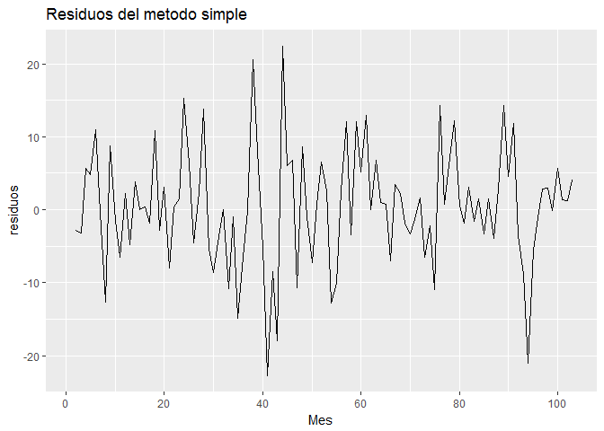

```r
    # Calculamos los residuos de los pronosticos ingenuos
    res<-residuals(naive(Cl(valor1)))
    # Grafica de residuos
    autoplot(res) + xlab("Mes") + ylab("residuos") +
        ggtitle("Residuos del metodo simple")
```

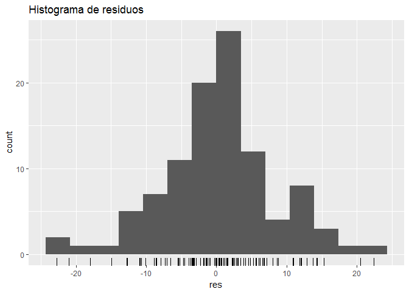

```r
    # Grafica de histograma de residuos
    gghistogram(res) + ggtitle("Histograma de residuos")
```

Podemos pintar un resumen de las anteriores gráficas con la función `checkresiduals()`.

```r
    # función checkresiduals
    Cl(valor1) %>% naive() %>% checkresiduals()
```

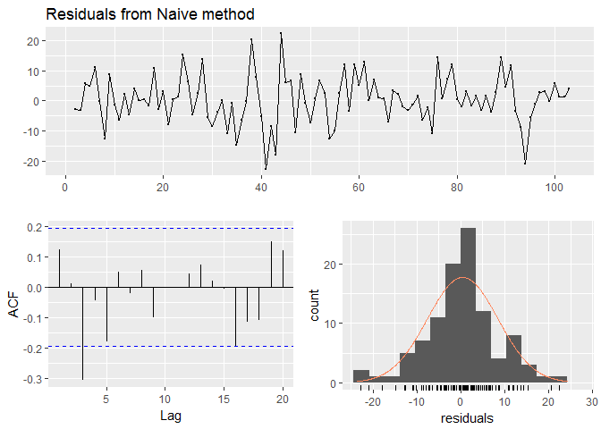

```
##
##  Ljung-Box test
##
## data:  Residuals from Naive method
## Q* = 16.958, df = 10, p-value = 0.07529
##
## Model df: 0.   Total lags used: 10
```

```r
    # Calculamos el test de Ljung
    Cl(valor1) %>% diff() %>% Box.test(lag=1,type= "Ljung")
```

```
##
##  Box-Ljung test
##
## data:  .
## X-squared = 1.6217, df = 1, p-value = 0.2029
```

## 6.2 Datos de entrenamiento vs prueba

Antes de comenzar a trabajar en un modelo de pronóstico sobre datos, es preciso dividir la muestra de observaciones o la serie temporal de partida en dos grupos:

1. un conjunto o varios para el **entrenamiento** del modelo
2. otro conjunto con datos diferentes de **prueba** del modelo

El conjunto de entrenamiento será el que nos de los párámetros finales de clibración del modelo y debe ser diferente al conjunto de prueba, pues de otro modo, estaríamos sobreajustando los parámetros y caeremos en lo que se denomina (en inglés) *overfitting*, sobreajuste.

No se puede evaluar la bondad de un modelo de predicción sobre datos que se han utilizado para calibrar el modelo, pues los resultados serían falsos, no adecuadso. Un modelo sobreajustado da muy buenos pronósticos en los datos de entrenamiento, pero suele dar malos en los datos de prueba. Esto indica que el modelo no ha detectado la señal principal en los datos y se ha centrado en el ruido, aunque tambien hay que comprobar que no exista un *bias* o desviación en los conjuntos de muestra.

Se logra por tanto un buen resultado, pero a costa de usar demasiados datos observables, lo que suele conllevar fallos en la predicción cuando se incluyen datos nuevos. El sobre-calibrado o sobreajuste es una muestra más del *principio de parsimonia*, o principio de la navaja de Ockham, que dice que en **igualdad de condiciones, la explicación más sencilla suele ser la más probable**.

Por esto es necesario **siempre** reservar una cantida de datos para descubrir sus posibles relaciones y calibrar el modelo y otro conjunto significativo de observaciones distintas para las pruebas del mismo.

### 6.2.1 Funciones para dividir una muestra

Una función que se puede usar para crear los grupos de entrenamiento y de prueba es `subset()` del paquete `forecast` en caso de series `ts`, que devuelve un subconjunto de una serie temporal donde los argumentos opcionales de inicio y fin se especifican usando valores de índice.

```r
    require("forecast")
    # convertimos los datos a ts
    observaciones<-ts(Cl(valor1))

    length(observaciones) # comprobamos la longitud de registros
```

```
## [1] 103
```

```r
    str(observaciones) # comprobamos el tipo de objeto
```

```
##  Time-Series [1:103, 1] from 1 to 103: 772 769 766 771 776 ...
##  - attr(*, "index")= atomic [1:103] 1473897600 1473984000 1474243200 1474329600 1474416000 ...
##   ..- attr(*, "tzone")= chr "UTC"
##   ..- attr(*, "tclass")= chr "Date"
##  - attr(*, ".indexTZ")= chr "UTC"
##  - attr(*, ".indexCLASS")= chr "Date"
##  - attr(*, "tclass")= chr "Date"
##  - attr(*, "tzone")= chr "UTC"
##  - attr(*, "src")= chr "yahoo"
##  - attr(*, "updated")= POSIXct[1:1], format: "2018-07-12 14:57:42"
##  - attr(*, "dimnames")=List of 2
##   ..$ : NULL
##   ..$ : chr "GOOG.Close"
```

```r
    # Creamos subconjunto de entrenamiento de las 50 primeras obsevaciones
    train<-subset(observaciones, end = 50)

    # Creamos subconjunto de prueba
    test<-subset(observaciones,start = 51, end = 103)

    # comprobamos la longitud de cada subconjunto
    length(train)
```

```
## [1] 50
```

```r
    length(test)
```

```
## [1] 53
```

Otra función que nos vale para dividir la muestra es `window()`, o las funciones típicas de data.frames como `head()` o `tail()` que nos permiten dividir series.

```r
    require("forecast")

    # Creamos subconjunto de entrenamiento y test
    # sobre las primeras 40 observaciones
    train<-window(observaciones, end = 40)
    test<-subset(observaciones, start = 41)

    # comprobamos la longitud de cada subconjunto
    print(paste("Num datos conjunto entrenamiento=", length(train)))
```

```
## [1] "Num datos conjunto entrenamiento= 40"
```

```r
    print(paste("Num datos conjunto prueba=", length(test)))
```

```
## [1] "Num datos conjunto prueba= 63"
```

## 6.3 Medidas del error de predicción

Dado que el residuo o error de las prediciones dependen de las escala de los datos observados, debemos buscar una fórmula que nos permita comparar diferentes modelos de ajuste sin la dependencia esta escala incial de los datos.

Hay varios indicadores en este sentido, por ejemplo los dos siguientes ns permiten comparar diferentes modelos en una misma serie, siendo el MAE más facil de interpretar.

- **MAE**(Mean absolute error) o valor absoluto medio del error
  $$MAE=media(|e_t|)$$
- **RMSE** o raiz cuadrada del error medio cuadrático =
  $$RMSE=\sqrt{media(e_t^2)}$$

Otras de las medidas como el MAPE permiten desescalar los resultados a porcentaje lo que pemite comparar diferentes series y modelos. Todas estas medidas tienen sus ventajas y desventajas, por ejemplo MAPE sobrevalora los errres positivos, o las escalas con un cero, por lo que hay otras mediciones como **sMAPE** o incluso el **MASE** que tratan de paliar estas consecuencias con mejores , pero más complejos estimadores.

- **MAPE** (mean absolute mean error)
  $$MAPE= mean(|100e_t/y_t|)$$
  este valor es el mejor par series con estacionalidad.

## 6.4 Precisión del modelo en series de tendencia

La función `accuracy(f,x,...)` del paquete `forecast`calcula varias estadísticas referentes al ajuste del pronóstico, dados las predicciones y también las observaciones reales correspondientes. Es una función muy completa a la que se le debe aportar como parámetros:

- **f** es un objeto de clase `forecast`
- **x** es un vector numérico o una serie temporal

Entre los estadísticos que da están los vistos en el aprtado anterior como RMSE, MSE etc… Cuanto menor sea el valor de esta medidas, por ejemplo de RMSE, mejor es el pronóstico, más se ajusta a lso datos observados.

Vamos a comparar dos modelos de pronostico con esta función para ver cual es el mejor.

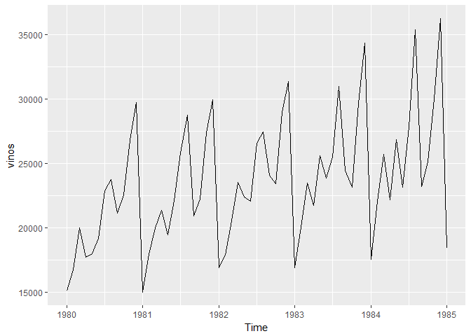

```r
    # Trabajaremos sobre la serie del ventas de vinos en Australia que ya usamos anteriormente
    # pintamos la serie
    vinos<-window(wineind,end=1985)
    autoplot(vinos)
```

```r
    # Longitud de la serie
    length(vinos)
```

```
## [1] 61
```

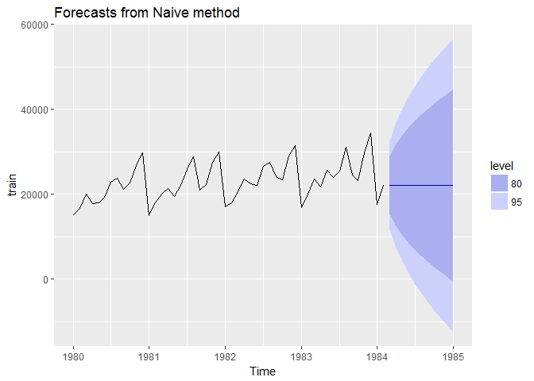

```r
    # Creamos el conjunto de entrenamiento
    train <- subset(vinos, end = 50)

    # 1. Metodo simple
    # Calculamos el pronostico ingenuo, para los proximos 11 intervalos
    pronos_s1 <- naive(train, h = 11)
    autoplot(pronos_s1)
```

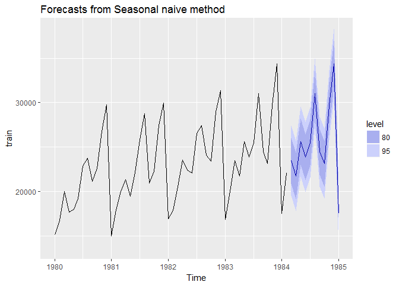

```r
    # 2. Metodo simple estacional
    # Calculamos el pronostico de media anterior
    pronos_s2 <- snaive(train, h = 11)
    autoplot(pronos_s2)
```

```r
    # 3. Comparamos resultados
    # Usamos accuracy()  para calcular el RMSE
    accuracy(pronos_s1, vinos)
```

```
##                     ME     RMSE      MAE       MPE     MAPE     MASE
## Training set  141.6531 5314.319 3833.041 -2.200382 18.18678 2.450546
## Test set     4671.7273 6977.012 5331.182 14.408067 17.98235 3.408340
##                    ACF1 Theil's U
## Training set -0.2390462        NA
## Test set     -0.2334582  1.035587
```

```r
    accuracy(pronos_s2, vinos)
```

```
##                    ME     RMSE      MAE      MPE     MAPE     MASE
## Training set 1284.053 2008.864 1564.158 5.295017 6.491853 1.000000
## Test set     1254.364 1954.547 1608.545 4.253698 5.780763 1.028378
##                    ACF1 Theil's U
## Training set -0.1997403        NA
## Test set     -0.4350287  0.285696
```

```r
    # Podemos acceder a valroes concetor
    accuracy(pronos_s1, wineind)["Test set", "MAPE"]
```

```
## [1] 17.98235
```

```r
    accuracy(pronos_s2, wineind)["Test set", "MAPE"]
```

```
## [1] 5.780763
```

```r
    checkresiduals(pronos_s2)
```

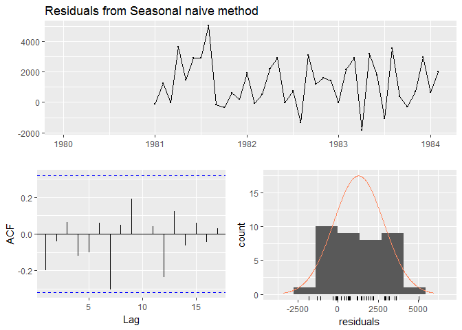

```
##
##  Ljung-Box test
##
## data:  Residuals from Seasonal naive method
## Q* = 21.658, df = 24, p-value = 0.5997
##
## Model df: 0.   Total lags used: 24
```

## 6.5 Validación cruzada con `tsCV()`

Otra de las funciones que nos permiten evaluar la bondad de un modelo de pronóstico es aplicar la validación cruzada a los datos de prueba. La función `tsCV()` (*En inglés time serie Cross Validation*) calcula los errores (es decir la diferencia entre el valor esperado y el observado) en un pronóstico realizado con una función determinada, para cada valor de la serie temporal.

```r
    # argumentos de la función tsCV()
    args(tsCV)
```

```
## function (y, forecastfunction, h = 1, window = NULL, ...)
## NULL
```

La validación cruzada consiste en aplicar calcular los pronósticos con datos de la serie de prueba tomando cada vez un elemento más de la misma serie, y tratandolos como series independientes. Es decir, considera como conjunto de entrenamiento todos los puntos de la serie hasta uno determinado, y con eso pronostica una serie de pasos adelante, y repite esta misma acción considerando un nuevo intervalo.

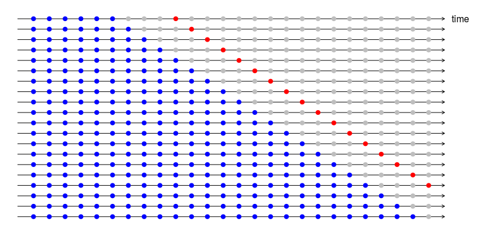

validacion cruzada con h=4

La llamada a la función `tsCV()` requiere que se de la *serie temporal*, el *método de pronóstico* y el *horizonte de pronóstico*. El resultado es una nueva serie con el error del valor pronosticado para cada intervalo de la serie temporal.

Haciendo estadísticas de estos errores podemos saber la precisión del modelo de pronóstico.

Veamos un ejemplo en el que calcularemos el MSE (Mean Square Error= erro medio al cuadrático). Lo de elevarlo al cuadrado es para obtener valor absoluto del error.

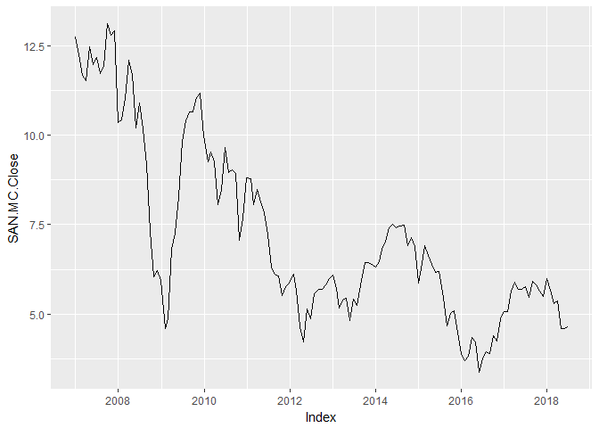

```r
    require(quantmod)
    #Leemos los datos de Santander en bolsa de Madrid
    acc1 <- getSymbols("SAN.MC",
                       src ="yahoo",
                       periodicity = "monthly",
                       warning= "FALSE",
                       adjust = TRUE,
                       auto.assign=FALSE)

    autoplot(acc1$SAN.MC.Close)
```

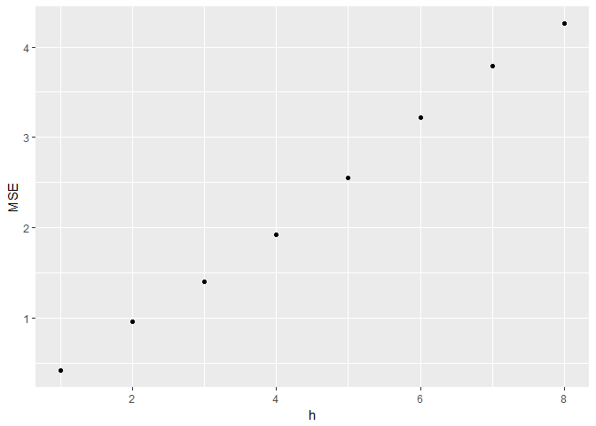

```r
   e <- matrix(NA_real_, nrow = length(acc1$SAN.MC.Close), ncol = 8)

    # Creamos una matriz que va a contener los errores de diferentes pronósticos.
    # en este caso haremos la validación cruzada para 8 pasos adelante
    # y necesitamos almacenarlo en una matriz de la misma longitud que la serie y 8 columnas
    # una por cada paso o pronostico
    # Creamos matriz de NA_reales
    for (h in 1:8){
      e[, h] <- tsCV(acc1$SAN.MC.Close, forecastfunction = naive, h = h)
    }

    # Calcularemos pel MSE ara cada pronostico
    mse <- colMeans(e^2, na.rm = TRUE)

    # Pintamos la evolución del MSE contra el horizonte de pronostico.
    data.frame(h = 1:8, MSE = mse) %>%
      ggplot(aes(x = h, y = MSE)) + geom_point()
```

Como vemos en el ejemplo anterior a mayor horizonte de pronsóstico, el error MSE es mayor.

## 6.6 Banda de predicción

Los graficos que estamos usando por defecto para representar pronósticos en la libraría `forecast` incluyen, no solo el valor predicho para cada horizonte de pronostico, sino también unas bandas de colores que indican los intervalos de predición del 80 y 95%.

Se trata de un rango de probabilidad en los que se espera que esté el pronostico, suponiendo que las prediciones tengan una distribución normal.

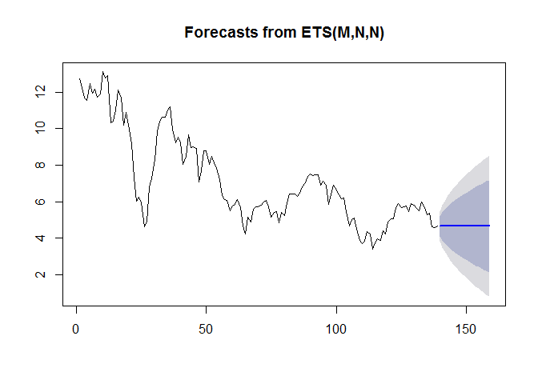

```r
    # Bandas de predición de pronóstico
    p.acc<-forecast(acc1$SAN.MC.Close,h=20)
    plot(p.acc)
```